# Risk Factor Analysis

## Outcome Variable

**Outcome Variable:** haz

## Predictor Variables

**Intervention Variable:** vagbrth

**Adjustment Set:**

- arm
- sex
- W_mage
- meducyrs
- feducyrs
- hhwealth_quart
- W_mhtcm
- W_mwtkg
- W_mbmi
- single
- W_nrooms
- brthmon
- W_parity
- impfloor
- delta_W_mage
- delta_meducyrs
- delta_feducyrs
- delta_hhwealth_quart
- delta_W_mhtcm
- delta_W_mwtkg
- delta_W_mbmi
- delta_single
- delta_W_nrooms
- delta_brthmon
- delta_W_parity
- delta_impfloor

## Stratifying Variables

The analysis was stratified on these variable(s):

- agecat
- studyid
- country

## Data Summary

| agecat | studyid | country | vagbrth | n_cell | n | outcome_variable |
| --- | --- | --- | --- | --- | --- | --- |
| Birth | CMC-V-BCS-2002 | INDIA | 0 | 11 | 92 | haz |
| Birth | CMC-V-BCS-2002 | INDIA | 1 | 81 | 92 | haz |
| Birth | IRC | INDIA | 0 | 68 | 388 | haz |
| Birth | IRC | INDIA | 1 | 320 | 388 | haz |
| Birth | JiVitA-3 | BANGLADESH | 0 | 539 | 22418 | haz |
| Birth | JiVitA-3 | BANGLADESH | 1 | 21879 | 22418 | haz |
| Birth | JiVitA-4 | BANGLADESH | 0 | 76 | 2822 | haz |
| Birth | JiVitA-4 | BANGLADESH | 1 | 2746 | 2822 | haz |
| Birth | NIH-Crypto | BANGLADESH | 0 | 186 | 477 | haz |
| Birth | NIH-Crypto | BANGLADESH | 1 | 291 | 477 | haz |
| Birth | PROBIT | BELARUS | 0 | 1597 | 13893 | haz |
| Birth | PROBIT | BELARUS | 1 | 12296 | 13893 | haz |
| Birth | PROVIDE | BANGLADESH | 0 | 108 | 539 | haz |
| Birth | PROVIDE | BANGLADESH | 1 | 431 | 539 | haz |
| Birth | ZVITAMBO | ZIMBABWE | 0 | 1166 | 13761 | haz |
| Birth | ZVITAMBO | ZIMBABWE | 1 | 12595 | 13761 | haz |
| 6 months | CMC-V-BCS-2002 | INDIA | 0 | 25 | 369 | haz |
| 6 months | CMC-V-BCS-2002 | INDIA | 1 | 344 | 369 | haz |
| 6 months | IRC | INDIA | 0 | 69 | 407 | haz |
| 6 months | IRC | INDIA | 1 | 338 | 407 | haz |
| 6 months | JiVitA-3 | BANGLADESH | 0 | 1077 | 16732 | haz |
| 6 months | JiVitA-3 | BANGLADESH | 1 | 15655 | 16732 | haz |
| 6 months | JiVitA-4 | BANGLADESH | 0 | 336 | 4052 | haz |
| 6 months | JiVitA-4 | BANGLADESH | 1 | 3716 | 4052 | haz |
| 6 months | NIH-Crypto | BANGLADESH | 0 | 187 | 457 | haz |
| 6 months | NIH-Crypto | BANGLADESH | 1 | 270 | 457 | haz |
| 6 months | PROBIT | BELARUS | 0 | 1799 | 15760 | haz |
| 6 months | PROBIT | BELARUS | 1 | 13961 | 15760 | haz |
| 6 months | PROVIDE | BANGLADESH | 0 | 139 | 604 | haz |
| 6 months | PROVIDE | BANGLADESH | 1 | 465 | 604 | haz |
| 6 months | TanzaniaChild2 | TANZANIA, UNITED REPUBLIC OF | 0 | 189 | 2005 | haz |
| 6 months | TanzaniaChild2 | TANZANIA, UNITED REPUBLIC OF | 1 | 1816 | 2005 | haz |
| 6 months | ZVITAMBO | ZIMBABWE | 0 | 740 | 8601 | haz |
| 6 months | ZVITAMBO | ZIMBABWE | 1 | 7861 | 8601 | haz |
| 24 months | CMC-V-BCS-2002 | INDIA | 0 | 24 | 371 | haz |
| 24 months | CMC-V-BCS-2002 | INDIA | 1 | 347 | 371 | haz |
| 24 months | IRC | INDIA | 0 | 69 | 409 | haz |
| 24 months | IRC | INDIA | 1 | 340 | 409 | haz |
| 24 months | JiVitA-3 | BANGLADESH | 0 | 480 | 8584 | haz |
| 24 months | JiVitA-3 | BANGLADESH | 1 | 8104 | 8584 | haz |
| 24 months | JiVitA-4 | BANGLADESH | 0 | 323 | 4020 | haz |
| 24 months | JiVitA-4 | BANGLADESH | 1 | 3697 | 4020 | haz |
| 24 months | NIH-Crypto | BANGLADESH | 0 | 99 | 260 | haz |
| 24 months | NIH-Crypto | BANGLADESH | 1 | 161 | 260 | haz |
| 24 months | PROBIT | BELARUS | 0 | 472 | 4035 | haz |
| 24 months | PROBIT | BELARUS | 1 | 3563 | 4035 | haz |
| 24 months | PROVIDE | BANGLADESH | 0 | 137 | 578 | haz |
| 24 months | PROVIDE | BANGLADESH | 1 | 441 | 578 | haz |
| 24 months | TanzaniaChild2 | TANZANIA, UNITED REPUBLIC OF | 0 | 2 | 6 | haz |
| 24 months | TanzaniaChild2 | TANZANIA, UNITED REPUBLIC OF | 1 | 4 | 6 | haz |
| 24 months | ZVITAMBO | ZIMBABWE | 0 | 133 | 1619 | haz |
| 24 months | ZVITAMBO | ZIMBABWE | 1 | 1486 | 1619 | haz |

The following strata were considered:

- agecat: 24 months, studyid: CMC-V-BCS-2002, country: INDIA
- agecat: 24 months, studyid: IRC, country: INDIA
- agecat: 24 months, studyid: JiVitA-3, country: BANGLADESH
- agecat: 24 months, studyid: JiVitA-4, country: BANGLADESH
- agecat: 24 months, studyid: NIH-Crypto, country: BANGLADESH
- agecat: 24 months, studyid: PROBIT, country: BELARUS
- agecat: 24 months, studyid: PROVIDE, country: BANGLADESH
- agecat: 24 months, studyid: TanzaniaChild2, country: TANZANIA, UNITED REPUBLIC OF
- agecat: 24 months, studyid: ZVITAMBO, country: ZIMBABWE
- agecat: 6 months, studyid: CMC-V-BCS-2002, country: INDIA
- agecat: 6 months, studyid: IRC, country: INDIA
- agecat: 6 months, studyid: JiVitA-3, country: BANGLADESH
- agecat: 6 months, studyid: JiVitA-4, country: BANGLADESH
- agecat: 6 months, studyid: NIH-Crypto, country: BANGLADESH
- agecat: 6 months, studyid: PROBIT, country: BELARUS
- agecat: 6 months, studyid: PROVIDE, country: BANGLADESH
- agecat: 6 months, studyid: TanzaniaChild2, country: TANZANIA, UNITED REPUBLIC OF
- agecat: 6 months, studyid: ZVITAMBO, country: ZIMBABWE
- agecat: Birth, studyid: CMC-V-BCS-2002, country: INDIA
- agecat: Birth, studyid: IRC, country: INDIA
- agecat: Birth, studyid: JiVitA-3, country: BANGLADESH
- agecat: Birth, studyid: JiVitA-4, country: BANGLADESH
- agecat: Birth, studyid: NIH-Crypto, country: BANGLADESH
- agecat: Birth, studyid: PROBIT, country: BELARUS
- agecat: Birth, studyid: PROVIDE, country: BANGLADESH
- agecat: Birth, studyid: ZVITAMBO, country: ZIMBABWE

### Dropped Strata

Some strata were dropped due to rare outcomes:

- agecat: 24 months, studyid: TanzaniaChild2, country: TANZANIA, UNITED REPUBLIC OF

## Methods Detail

We’re interested in the causal parameters $E[Y_a]$ for all values of $a \in \mathcal{A}$. These parameters represent the mean outcome if, possibly contrary to fact, we intervened to set all units to have $A=a$. Under the randomization and positivity assumptions, these are identified by the statistical parameters $\psi_a=E_W[E_{Y|A,W}(Y|A=a,W)]$. In addition, we’re interested in the mean of $Y$, $E[Y]$ under no intervention (the observed mean). We will estimate these parameters by using SuperLearner to fit the relevant likelihood factors – $E_{Y|A,W}(Y|A=a,W)$ and $p(A=a|W)$, and then updating our likelihood fit using a joint TMLE.

For unadjusted analyses ($W=\{\}$), initial likelihoods were estimated using Lrnr_glm to estimate the simple $E(Y|A)$ and Lrnr_mean to estimate $p(A)$. For adjusted analyses, a small library containing Lrnr_glmnet, Lrnr_xgboost, and Lrnr_mean was used.

Having estimated these parameters, we will then use the delta method to estimate relative risks and attributable risks relative to a prespecified baseline level of $A$.

# Results Detail

## Results Plots

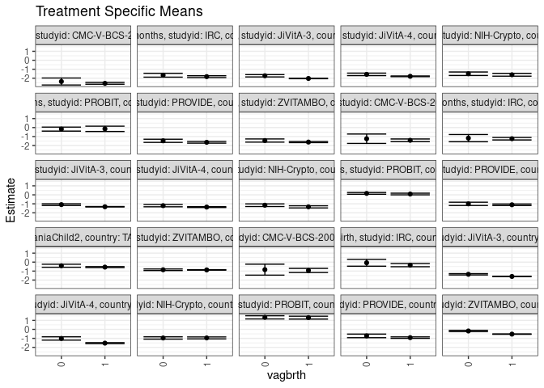

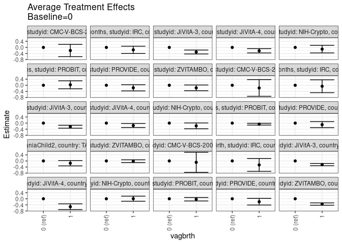

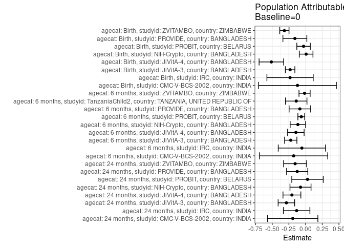

## Results Table

### Parameter: TSM

| agecat | studyid | country | intervention_level | baseline_level | estimate | ci_lower | ci_upper |
| --- | --- | --- | --- | --- | --- | --- | --- |
| Birth | CMC-V-BCS-2002 | INDIA | 0 | NA | -0.8396854 | -1.4508393 | -0.2285315 |
| Birth | CMC-V-BCS-2002 | INDIA | 1 | NA | -0.9305187 | -1.1629937 | -0.6980438 |
| Birth | IRC | INDIA | 0 | NA | -0.0753282 | -0.4580182 | 0.3073619 |
| Birth | IRC | INDIA | 1 | NA | -0.3371206 | -0.5137386 | -0.1605025 |
| Birth | JiVitA-3 | BANGLADESH | 0 | NA | -1.3574057 | -1.4297108 | -1.2851006 |
| Birth | JiVitA-3 | BANGLADESH | 1 | NA | -1.5963179 | -1.6158855 | -1.5767503 |
| Birth | JiVitA-4 | BANGLADESH | 0 | NA | -1.0101112 | -1.1945750 | -0.8256474 |
| Birth | JiVitA-4 | BANGLADESH | 1 | NA | -1.5317508 | -1.5823714 | -1.4811302 |
| Birth | NIH-Crypto | BANGLADESH | 0 | NA | -0.9561693 | -1.0849549 | -0.8273837 |
| Birth | NIH-Crypto | BANGLADESH | 1 | NA | -0.9494133 | -1.0557822 | -0.8430445 |
| Birth | PROBIT | BELARUS | 0 | NA | 1.3417197 | 1.1626978 | 1.5207415 |
| Birth | PROBIT | BELARUS | 1 | NA | 1.3107496 | 1.1494457 | 1.4720536 |
| Birth | PROVIDE | BANGLADESH | 0 | NA | -0.7246547 | -0.9269460 | -0.5223635 |
| Birth | PROVIDE | BANGLADESH | 1 | NA | -0.9179386 | -0.9991285 | -0.8367487 |
| Birth | ZVITAMBO | ZIMBABWE | 0 | NA | -0.1792421 | -0.2516379 | -0.1068462 |
| Birth | ZVITAMBO | ZIMBABWE | 1 | NA | -0.5268418 | -0.5483830 | -0.5053006 |
| 6 months | CMC-V-BCS-2002 | INDIA | 0 | NA | -1.2446404 | -1.7685049 | -0.7207758 |
| 6 months | CMC-V-BCS-2002 | INDIA | 1 | NA | -1.4210355 | -1.5679444 | -1.2741266 |
| 6 months | IRC | INDIA | 0 | NA | -1.1787025 | -1.5789323 | -0.7784726 |
| 6 months | IRC | INDIA | 1 | NA | -1.2438937 | -1.3807794 | -1.1070080 |
| 6 months | JiVitA-3 | BANGLADESH | 0 | NA | -1.0909245 | -1.1855103 | -0.9963386 |
| 6 months | JiVitA-3 | BANGLADESH | 1 | NA | -1.3285416 | -1.3518142 | -1.3052691 |
| 6 months | JiVitA-4 | BANGLADESH | 0 | NA | -1.2044374 | -1.3318495 | -1.0770253 |
| 6 months | JiVitA-4 | BANGLADESH | 1 | NA | -1.3633770 | -1.4075582 | -1.3191957 |
| 6 months | NIH-Crypto | BANGLADESH | 0 | NA | -1.1577447 | -1.3052216 | -1.0102678 |
| 6 months | NIH-Crypto | BANGLADESH | 1 | NA | -1.3386508 | -1.4594881 | -1.2178136 |
| 6 months | PROBIT | BELARUS | 0 | NA | 0.1618822 | 0.0636392 | 0.2601253 |
| 6 months | PROBIT | BELARUS | 1 | NA | 0.0909269 | -0.0014795 | 0.1833333 |
| 6 months | PROVIDE | BANGLADESH | 0 | NA | -1.0061332 | -1.1876493 | -0.8246172 |
| 6 months | PROVIDE | BANGLADESH | 1 | NA | -1.1075199 | -1.1922027 | -1.0228371 |
| 6 months | TanzaniaChild2 | TANZANIA, UNITED REPUBLIC OF | 0 | NA | -0.4054024 | -0.5737105 | -0.2370943 |
| 6 months | TanzaniaChild2 | TANZANIA, UNITED REPUBLIC OF | 1 | NA | -0.5555090 | -0.6073304 | -0.5036875 |
| 6 months | ZVITAMBO | ZIMBABWE | 0 | NA | -0.8534403 | -0.9404381 | -0.7664424 |
| 6 months | ZVITAMBO | ZIMBABWE | 1 | NA | -0.8701142 | -0.8970517 | -0.8431767 |
| 24 months | CMC-V-BCS-2002 | INDIA | 0 | NA | -2.3663646 | -2.7558139 | -1.9769154 |
| 24 months | CMC-V-BCS-2002 | INDIA | 1 | NA | -2.5685234 | -2.6713198 | -2.4657269 |
| 24 months | IRC | INDIA | 0 | NA | -1.6649274 | -1.8805559 | -1.4492989 |
| 24 months | IRC | INDIA | 1 | NA | -1.8236305 | -1.9266721 | -1.7205888 |
| 24 months | JiVitA-3 | BANGLADESH | 0 | NA | -1.7267397 | -1.8551602 | -1.5983192 |
| 24 months | JiVitA-3 | BANGLADESH | 1 | NA | -2.0269637 | -2.0545639 | -1.9993635 |
| 24 months | JiVitA-4 | BANGLADESH | 0 | NA | -1.5686264 | -1.7074594 | -1.4297935 |
| 24 months | JiVitA-4 | BANGLADESH | 1 | NA | -1.7876790 | -1.8272156 | -1.7481424 |
| 24 months | NIH-Crypto | BANGLADESH | 0 | NA | -1.5016723 | -1.6968504 | -1.3064942 |
| 24 months | NIH-Crypto | BANGLADESH | 1 | NA | -1.6136379 | -1.7701692 | -1.4571066 |
| 24 months | PROBIT | BELARUS | 0 | NA | -0.1733570 | -0.3963955 | 0.0496816 |
| 24 months | PROBIT | BELARUS | 1 | NA | -0.1418281 | -0.4381449 | 0.1544886 |
| 24 months | PROVIDE | BANGLADESH | 0 | NA | -1.4770189 | -1.6555633 | -1.2984745 |
| 24 months | PROVIDE | BANGLADESH | 1 | NA | -1.6427588 | -1.7378978 | -1.5476198 |
| 24 months | ZVITAMBO | ZIMBABWE | 0 | NA | -1.4475999 | -1.6264788 | -1.2687210 |
| 24 months | ZVITAMBO | ZIMBABWE | 1 | NA | -1.6179203 | -1.6780074 | -1.5578332 |

### Parameter: E(Y)

| agecat | studyid | country | intervention_level | baseline_level | estimate | ci_lower | ci_upper |
| --- | --- | --- | --- | --- | --- | --- | --- |
| Birth | CMC-V-BCS-2002 | INDIA | NA | NA | -0.9611957 | -1.1776967 | -0.7446946 |
| Birth | IRC | INDIA | NA | NA | -0.3080412 | -0.4687931 | -0.1472894 |
| Birth | JiVitA-3 | BANGLADESH | NA | NA | -1.5892417 | -1.6084834 | -1.5700000 |
| Birth | JiVitA-4 | BANGLADESH | NA | NA | -1.5231680 | -1.5722488 | -1.4740872 |
| Birth | NIH-Crypto | BANGLADESH | NA | NA | -0.9480084 | -1.0301396 | -0.8658772 |
| Birth | PROBIT | BELARUS | NA | NA | 1.3114417 | 1.1524752 | 1.4704082 |
| Birth | PROVIDE | BANGLADESH | NA | NA | -0.8851020 | -0.9601332 | -0.8100709 |
| Birth | ZVITAMBO | ZIMBABWE | NA | NA | -0.4970772 | -0.5177022 | -0.4764523 |
| 6 months | CMC-V-BCS-2002 | INDIA | NA | NA | -1.4234508 | -1.5645974 | -1.2823042 |
| 6 months | IRC | INDIA | NA | NA | -1.2344062 | -1.3658524 | -1.1029600 |
| 6 months | JiVitA-3 | BANGLADESH | NA | NA | -1.3134013 | -1.3366073 | -1.2901952 |
| 6 months | JiVitA-4 | BANGLADESH | NA | NA | -1.3500888 | -1.3921730 | -1.3080047 |
| 6 months | NIH-Crypto | BANGLADESH | NA | NA | -1.2731619 | -1.3626957 | -1.1836282 |
| 6 months | PROBIT | BELARUS | NA | NA | 0.0980074 | 0.0062724 | 0.1897424 |
| 6 months | PROVIDE | BANGLADESH | NA | NA | -1.0916915 | -1.1661176 | -1.0172654 |
| 6 months | TanzaniaChild2 | TANZANIA, UNITED REPUBLIC OF | NA | NA | -0.5455565 | -0.5948696 | -0.4962435 |
| 6 months | ZVITAMBO | ZIMBABWE | NA | NA | -0.8685914 | -0.8942954 | -0.8428875 |
| 24 months | CMC-V-BCS-2002 | INDIA | NA | NA | -2.5588679 | -2.6583730 | -2.4593629 |
| 24 months | IRC | INDIA | NA | NA | -1.7987775 | -1.8923914 | -1.7051636 |
| 24 months | JiVitA-3 | BANGLADESH | NA | NA | -2.0144245 | -2.0420946 | -1.9867544 |
| 24 months | JiVitA-4 | BANGLADESH | NA | NA | -1.7734527 | -1.8119258 | -1.7349797 |
| 24 months | NIH-Crypto | BANGLADESH | NA | NA | -1.5776538 | -1.6988448 | -1.4564629 |
| 24 months | PROBIT | BELARUS | NA | NA | -0.1442891 | -0.4253755 | 0.1367972 |
| 24 months | PROVIDE | BANGLADESH | NA | NA | -1.6024221 | -1.6857420 | -1.5191023 |
| 24 months | ZVITAMBO | ZIMBABWE | NA | NA | -1.6043391 | -1.6616652 | -1.5470130 |

### Parameter: ATE

| agecat | studyid | country | intervention_level | baseline_level | estimate | ci_lower | ci_upper |
| --- | --- | --- | --- | --- | --- | --- | --- |
| Birth | CMC-V-BCS-2002 | INDIA | 0 | 0 | 0.0000000 | 0.0000000 | 0.0000000 |
| Birth | CMC-V-BCS-2002 | INDIA | 1 | 0 | -0.0908334 | -0.7488899 | 0.5672231 |
| Birth | IRC | INDIA | 0 | 0 | 0.0000000 | 0.0000000 | 0.0000000 |
| Birth | IRC | INDIA | 1 | 0 | -0.2617924 | -0.6833663 | 0.1597814 |
| Birth | JiVitA-3 | BANGLADESH | 0 | 0 | 0.0000000 | 0.0000000 | 0.0000000 |
| Birth | JiVitA-3 | BANGLADESH | 1 | 0 | -0.2389122 | -0.3124998 | -0.1653246 |
| Birth | JiVitA-4 | BANGLADESH | 0 | 0 | 0.0000000 | 0.0000000 | 0.0000000 |
| Birth | JiVitA-4 | BANGLADESH | 1 | 0 | -0.5216396 | -0.7124146 | -0.3308646 |
| Birth | NIH-Crypto | BANGLADESH | 0 | 0 | 0.0000000 | 0.0000000 | 0.0000000 |
| Birth | NIH-Crypto | BANGLADESH | 1 | 0 | 0.0067560 | -0.1600562 | 0.1735681 |
| Birth | PROBIT | BELARUS | 0 | 0 | 0.0000000 | 0.0000000 | 0.0000000 |
| Birth | PROBIT | BELARUS | 1 | 0 | -0.0309700 | -0.1451306 | 0.0831905 |
| Birth | PROVIDE | BANGLADESH | 0 | 0 | 0.0000000 | 0.0000000 | 0.0000000 |
| Birth | PROVIDE | BANGLADESH | 1 | 0 | -0.1932838 | -0.4114018 | 0.0248341 |
| Birth | ZVITAMBO | ZIMBABWE | 0 | 0 | 0.0000000 | 0.0000000 | 0.0000000 |
| Birth | ZVITAMBO | ZIMBABWE | 1 | 0 | -0.3475998 | -0.4230090 | -0.2721906 |
| 6 months | CMC-V-BCS-2002 | INDIA | 0 | 0 | 0.0000000 | 0.0000000 | 0.0000000 |
| 6 months | CMC-V-BCS-2002 | INDIA | 1 | 0 | -0.1763951 | -0.7235848 | 0.3707945 |
| 6 months | IRC | INDIA | 0 | 0 | 0.0000000 | 0.0000000 | 0.0000000 |
| 6 months | IRC | INDIA | 1 | 0 | -0.0651913 | -0.4874711 | 0.3570886 |
| 6 months | JiVitA-3 | BANGLADESH | 0 | 0 | 0.0000000 | 0.0000000 | 0.0000000 |
| 6 months | JiVitA-3 | BANGLADESH | 1 | 0 | -0.2376172 | -0.3336106 | -0.1416238 |
| 6 months | JiVitA-4 | BANGLADESH | 0 | 0 | 0.0000000 | 0.0000000 | 0.0000000 |
| 6 months | JiVitA-4 | BANGLADESH | 1 | 0 | -0.1589396 | -0.2926049 | -0.0252744 |
| 6 months | NIH-Crypto | BANGLADESH | 0 | 0 | 0.0000000 | 0.0000000 | 0.0000000 |
| 6 months | NIH-Crypto | BANGLADESH | 1 | 0 | -0.1809061 | -0.3720178 | 0.0102056 |
| 6 months | PROBIT | BELARUS | 0 | 0 | 0.0000000 | 0.0000000 | 0.0000000 |
| 6 months | PROBIT | BELARUS | 1 | 0 | -0.0709554 | -0.1292035 | -0.0127072 |
| 6 months | PROVIDE | BANGLADESH | 0 | 0 | 0.0000000 | 0.0000000 | 0.0000000 |
| 6 months | PROVIDE | BANGLADESH | 1 | 0 | -0.1013866 | -0.3009196 | 0.0981463 |
| 6 months | TanzaniaChild2 | TANZANIA, UNITED REPUBLIC OF | 0 | 0 | 0.0000000 | 0.0000000 | 0.0000000 |
| 6 months | TanzaniaChild2 | TANZANIA, UNITED REPUBLIC OF | 1 | 0 | -0.1501066 | -0.3257681 | 0.0255549 |
| 6 months | ZVITAMBO | ZIMBABWE | 0 | 0 | 0.0000000 | 0.0000000 | 0.0000000 |
| 6 months | ZVITAMBO | ZIMBABWE | 1 | 0 | -0.0166739 | -0.1072502 | 0.0739023 |
| 24 months | CMC-V-BCS-2002 | INDIA | 0 | 0 | 0.0000000 | 0.0000000 | 0.0000000 |
| 24 months | CMC-V-BCS-2002 | INDIA | 1 | 0 | -0.2021587 | -0.6050186 | 0.2007011 |
| 24 months | IRC | INDIA | 0 | 0 | 0.0000000 | 0.0000000 | 0.0000000 |
| 24 months | IRC | INDIA | 1 | 0 | -0.1587031 | -0.3972182 | 0.0798120 |
| 24 months | JiVitA-3 | BANGLADESH | 0 | 0 | 0.0000000 | 0.0000000 | 0.0000000 |
| 24 months | JiVitA-3 | BANGLADESH | 1 | 0 | -0.3002240 | -0.4292329 | -0.1712151 |
| 24 months | JiVitA-4 | BANGLADESH | 0 | 0 | 0.0000000 | 0.0000000 | 0.0000000 |
| 24 months | JiVitA-4 | BANGLADESH | 1 | 0 | -0.2190526 | -0.3614553 | -0.0766499 |
| 24 months | NIH-Crypto | BANGLADESH | 0 | 0 | 0.0000000 | 0.0000000 | 0.0000000 |
| 24 months | NIH-Crypto | BANGLADESH | 1 | 0 | -0.1119656 | -0.3600128 | 0.1360816 |
| 24 months | PROBIT | BELARUS | 0 | 0 | 0.0000000 | 0.0000000 | 0.0000000 |
| 24 months | PROBIT | BELARUS | 1 | 0 | 0.0315288 | -0.2301520 | 0.2932096 |
| 24 months | PROVIDE | BANGLADESH | 0 | 0 | 0.0000000 | 0.0000000 | 0.0000000 |
| 24 months | PROVIDE | BANGLADESH | 1 | 0 | -0.1657400 | -0.3674798 | 0.0359998 |
| 24 months | ZVITAMBO | ZIMBABWE | 0 | 0 | 0.0000000 | 0.0000000 | 0.0000000 |
| 24 months | ZVITAMBO | ZIMBABWE | 1 | 0 | -0.1703204 | -0.3579360 | 0.0172951 |

### Parameter: PAR

| agecat | studyid | country | intervention_level | baseline_level | estimate | ci_lower | ci_upper |
| --- | --- | --- | --- | --- | --- | --- | --- |
| Birth | CMC-V-BCS-2002 | INDIA | 0 | NA | -0.1215103 | -0.7046726 | 0.4616521 |
| Birth | IRC | INDIA | 0 | NA | -0.2327131 | -0.5797520 | 0.1143258 |
| Birth | JiVitA-3 | BANGLADESH | 0 | NA | -0.2318360 | -0.3030155 | -0.1606564 |
| Birth | JiVitA-4 | BANGLADESH | 0 | NA | -0.5130568 | -0.6972171 | -0.3288965 |
| Birth | NIH-Crypto | BANGLADESH | 0 | NA | 0.0081609 | -0.0944103 | 0.1107321 |
| Birth | PROBIT | BELARUS | 0 | NA | -0.0302779 | -0.1311986 | 0.0706427 |
| Birth | PROVIDE | BANGLADESH | 0 | NA | -0.1604473 | -0.3399272 | 0.0190326 |
| Birth | ZVITAMBO | ZIMBABWE | 0 | NA | -0.3178352 | -0.3873262 | -0.2483442 |
| 6 months | CMC-V-BCS-2002 | INDIA | 0 | NA | -0.1788104 | -0.6899968 | 0.3323760 |
| 6 months | IRC | INDIA | 0 | NA | -0.0557038 | -0.4099607 | 0.2985532 |
| 6 months | JiVitA-3 | BANGLADESH | 0 | NA | -0.2224768 | -0.3146079 | -0.1303457 |
| 6 months | JiVitA-4 | BANGLADESH | 0 | NA | -0.1456515 | -0.2692552 | -0.0220478 |
| 6 months | NIH-Crypto | BANGLADESH | 0 | NA | -0.1154172 | -0.2313318 | 0.0004973 |
| 6 months | PROBIT | BELARUS | 0 | NA | -0.0638748 | -0.1151888 | -0.0125609 |
| 6 months | PROVIDE | BANGLADESH | 0 | NA | -0.0855583 | -0.2470426 | 0.0759261 |
| 6 months | TanzaniaChild2 | TANZANIA, UNITED REPUBLIC OF | 0 | NA | -0.1401541 | -0.3010543 | 0.0207460 |
| 6 months | ZVITAMBO | ZIMBABWE | 0 | NA | -0.0151512 | -0.0987348 | 0.0684324 |
| 24 months | CMC-V-BCS-2002 | INDIA | 0 | NA | -0.1925033 | -0.5693812 | 0.1843746 |
| 24 months | IRC | INDIA | 0 | NA | -0.1338501 | -0.3326304 | 0.0649301 |
| 24 months | JiVitA-3 | BANGLADESH | 0 | NA | -0.2876848 | -0.4115183 | -0.1638513 |
| 24 months | JiVitA-4 | BANGLADESH | 0 | NA | -0.2048263 | -0.3389016 | -0.0707510 |
| 24 months | NIH-Crypto | BANGLADESH | 0 | NA | -0.0759816 | -0.2337688 | 0.0818056 |
| 24 months | PROBIT | BELARUS | 0 | NA | 0.0290678 | -0.2065297 | 0.2646654 |
| 24 months | PROVIDE | BANGLADESH | 0 | NA | -0.1254033 | -0.2844274 | 0.0336208 |
| 24 months | ZVITAMBO | ZIMBABWE | 0 | NA | -0.1567392 | -0.3293374 | 0.0158590 |